# HW7_SUNG_PINGYI

```python
import pandas as pd
import numpy as ny
import re
```

```python
data = pd.read_csv(r'/Users/apple/Desktop/HW7_Food Inspection.csv',delimiter=',',engine='python', encoding='utf-8')
data
```

|  | Establishment_id | Name | Category | Inspection_date | Inspection_results | City | State | Zip | Address_line_1 | Address_line_2 | ... | Proper_sewage_disposal | No_bare_hand_contact | Adequate_hand_washing_facilities | Rodent_and_insects | Food_contact_surfaces_and_equipment | Inspection_type | Owner | Type | Location | Zip Codes |
| --- | --- | --- | --- | --- | --- | --- | --- | --- | --- | --- | --- | --- | --- | --- | --- | --- | --- | --- | --- | --- | --- |
| 0 | 8176 | LAUREL DUTCH MARKET - SAMMIE'S PRODUCE | Carry-out | 09/05/2019 12:00:00 AM | Critical Violations observed | LAUREL | MD | 20707.0 | 9701 FORT MEADE RD | ------ | ... | In Compliance | In Compliance | In Compliance | In Compliance | In Compliance | Monitoring | Samuel Stoltzfus | Food Establishments | POINT (-76.838165 39.095491) | 15996.0 |
| 1 | 14622 | JERSEY MIKE'S SUBS | Fast Food | 09/06/2019 12:00:00 AM | Critical Violations observed | Riverdale | MD | 20737.0 | 6761 45th ST | ------ | ... | In Compliance | In Compliance | In Compliance | In Compliance | In Compliance | Re-inspection | DANIEL MALAMIS | Food Establishments | NaN | NaN |
| 2 | 7273 | ACCOKEEK ACADEMY | Public School | 09/09/2019 12:00:00 AM | Non-Compliant - Violations Observed | ACCOKEEK | MD | 20607.0 | 14400 BERRY RD | ------ | ... | In Compliance | In Compliance | In Compliance | In Compliance | In Compliance | Comprehensive | MARK FOSSETT | Food Establishments | POINT (-76.980676 38.687531) | 8834.0 |
| 3 | 2103 | PAPA JOHNS 728 | Carry-out | 09/05/2019 12:00:00 AM | Compliant - No Health Risk | BOWIE | MD | 20715.0 | 6852 RACE TRACK RD | ------ | ... | In Compliance | In Compliance | In Compliance | In Compliance | In Compliance | Re-inspection | Annie Berkovicz | Food Establishments | POINT (-76.729269 38.983881) | 16435.0 |
| 4 | 347 | COLUMBIA PARK ELEMENTARY SCHOOL | Public School | 09/05/2019 12:00:00 AM | Critical Violations observed | LANDOVER | MD | 20785.0 | 1901 KENT VILLAGE DR | ------ | ... | In Compliance | In Compliance | In Compliance | Out of Compliance | In Compliance | Comprehensive | MARK FOSSETT | Food Establishments | POINT (-76.88767 38.91584) | 31451.0 |
| ... | ... | ... | ... | ... | ... | ... | ... | ... | ... | ... | ... | ... | ... | ... | ... | ... | ... | ... | ... | ... | ... |
| 34731 | 2227 | SEVEN ELEVEN 11657B | Convenience Store | 08/29/2019 12:00:00 AM | Critical Violations observed | LANDOVER | MD | 20785.0 | 6001 ARBOR ST | ------ | ... | In Compliance | In Compliance | In Compliance | In Compliance | Out of Compliance | Monitoring | GEREMEW DAWIT | Food Establishments | POINT (-76.916124 38.918599) | 31451.0 |
| 34732 | 1161 | POLLO CABANA | Carry-out | 08/29/2019 12:00:00 AM | ------ | GREENBELT | MD | 20770.0 | 7423 GREENBELT RD | ------ | ... | In Compliance | In Compliance | In Compliance | In Compliance | In Compliance | NaN | RAHIL SAYADI | Food Establishments | POINT (-76.881531 38.994883) | 16242.0 |
| 34733 | 8320 | PAISANOS COLLEGE PARK | Full Service | 08/26/2019 12:00:00 AM | Compliance Schedule - Completed | COLLEGE PARK | MD | 20740.0 | 7201 BALTIMORE AVE | B | ... | In Compliance | In Compliance | In Compliance | In Compliance | In Compliance | Re-inspection | FOUAD QRETIN | Food Establishments | POINT (-76.93784 38.977805) | 15305.0 |
| 34734 | 2268 | SIX FLAGS AMERICA - HURRICANE HOT DOGS | Stadium/Amusement Park | 08/24/2019 12:00:00 AM | Non-Compliant - Violations Observed | MITCHELLVILLE | MD | 20721.0 | 13710 CENTRAL AVE | ------ | ... | In Compliance | In Compliance | In Compliance | In Compliance | In Compliance | NaN | RICK HOWARTH | Food Establishments | POINT (-76.775193 38.90087) | 17158.0 |
| 34735 | 2511 | CVS PHARMACY 1489 | Convenience Store | 08/28/2019 12:00:00 AM | Non-Compliant - Violations Observed | LANDOVER | MD | 20785.0 | 6516 LANDOVER RD | ------ | ... | In Compliance | In Compliance | In Compliance | In Compliance | In Compliance | Comprehensive | RUTH PAREDES | Food Establishments | POINT (-76.900997 38.931946) | 31451.0 |

34736 rows × 30 columns

# Clean the data, make it easier to read and crerate columns for further analysis

# 1a. create a table of the unique values of category

```python
data['Category'].unique()
```

```
array(['Carry-out', 'Fast Food', 'Public School', 'Hotel', nan,
       'Grocery Store', 'Convenience Store', 'Full Service', 'Ice Cream',
       'Bakery/Catering', 'Gas Station Store', 'College/University',
       'Restaurant', 'Health Care Facility', 'Bar/Tavern/Lounge',
       'Dollar Store', 'Bakery', 'Private School', 'Coffee Shop',
       'Stadium/Amusement Park', 'Limited Service', 'Casino',
       'Church/Temple/Mosque', 'Catering Only', 'Cafeteria', 'Group Home',
       'Meat/Poultry Market', 'Snack Bar/Concession Stand',
       'Multiple Facilities', 'Pre-Packaged Only', 'Deli', 'Private Club',
       'Fire/Community Hall', 'Banquet Hall/Ballroom', 'Seafood',
       'Institution', 'After School Supper Program',
       'Senior Nutrition Program', 'Membership Warehouse',
       'Fast Food - Chain', 'Full Service/Catering', 'Specialty Store',
       'Buffet', 'Pizza', 'Grocery Store- Medium', 'Fast Food - Local',
       'Grocery Store - Large', 'Diet/Nutrition Site', 'Delivery Only',
       'Night Club', '@Full Service', 'Diner', 'Donut', 'Excluded',
       "Farmer's Market", 'Micro Market', 'B & B', 'School'], dtype=object)
```

I think the categories that represent will be : Fast Food, Bakery, Catering, Bar/Tavern/Lounge, Seafood,Buffet, Pizza, Diner, Restaurant, since these are the ones that can tell us what kind of food the restaurant is selling or what type of restaurant they are.

```python
#Create a dummy that combines multiple value from Category
data['MultiValue or Not']= data['Category'].str.contains('/',regex= True)
data
data['Dummies']= pd.get_dummies(data['MultiValue or Not']).iloc[:,1]
```

```python
data
```

|  | Establishment_id | Name | Category | Inspection_date | Inspection_results | City | State | Zip | Address_line_1 | Address_line_2 | ... | Adequate_hand_washing_facilities | Rodent_and_insects | Food_contact_surfaces_and_equipment | Inspection_type | Owner | Type | Location | Zip Codes | MultiValue or Not | Dummies |
| --- | --- | --- | --- | --- | --- | --- | --- | --- | --- | --- | --- | --- | --- | --- | --- | --- | --- | --- | --- | --- | --- |
| 0 | 8176 | LAUREL DUTCH MARKET - SAMMIE'S PRODUCE | Carry-out | 09/05/2019 12:00:00 AM | Critical Violations observed | LAUREL | MD | 20707.0 | 9701 FORT MEADE RD | ------ | ... | In Compliance | In Compliance | In Compliance | Monitoring | Samuel Stoltzfus | Food Establishments | POINT (-76.838165 39.095491) | 15996.0 | False | 0 |
| 1 | 14622 | JERSEY MIKE'S SUBS | Fast Food | 09/06/2019 12:00:00 AM | Critical Violations observed | Riverdale | MD | 20737.0 | 6761 45th ST | ------ | ... | In Compliance | In Compliance | In Compliance | Re-inspection | DANIEL MALAMIS | Food Establishments | NaN | NaN | False | 0 |
| 2 | 7273 | ACCOKEEK ACADEMY | Public School | 09/09/2019 12:00:00 AM | Non-Compliant - Violations Observed | ACCOKEEK | MD | 20607.0 | 14400 BERRY RD | ------ | ... | In Compliance | In Compliance | In Compliance | Comprehensive | MARK FOSSETT | Food Establishments | POINT (-76.980676 38.687531) | 8834.0 | False | 0 |
| 3 | 2103 | PAPA JOHNS 728 | Carry-out | 09/05/2019 12:00:00 AM | Compliant - No Health Risk | BOWIE | MD | 20715.0 | 6852 RACE TRACK RD | ------ | ... | In Compliance | In Compliance | In Compliance | Re-inspection | Annie Berkovicz | Food Establishments | POINT (-76.729269 38.983881) | 16435.0 | False | 0 |
| 4 | 347 | COLUMBIA PARK ELEMENTARY SCHOOL | Public School | 09/05/2019 12:00:00 AM | Critical Violations observed | LANDOVER | MD | 20785.0 | 1901 KENT VILLAGE DR | ------ | ... | In Compliance | Out of Compliance | In Compliance | Comprehensive | MARK FOSSETT | Food Establishments | POINT (-76.88767 38.91584) | 31451.0 | False | 0 |
| ... | ... | ... | ... | ... | ... | ... | ... | ... | ... | ... | ... | ... | ... | ... | ... | ... | ... | ... | ... | ... | ... |
| 34731 | 2227 | SEVEN ELEVEN 11657B | Convenience Store | 08/29/2019 12:00:00 AM | Critical Violations observed | LANDOVER | MD | 20785.0 | 6001 ARBOR ST | ------ | ... | In Compliance | In Compliance | Out of Compliance | Monitoring | GEREMEW DAWIT | Food Establishments | POINT (-76.916124 38.918599) | 31451.0 | False | 0 |
| 34732 | 1161 | POLLO CABANA | Carry-out | 08/29/2019 12:00:00 AM | ------ | GREENBELT | MD | 20770.0 | 7423 GREENBELT RD | ------ | ... | In Compliance | In Compliance | In Compliance | NaN | RAHIL SAYADI | Food Establishments | POINT (-76.881531 38.994883) | 16242.0 | False | 0 |
| 34733 | 8320 | PAISANOS COLLEGE PARK | Full Service | 08/26/2019 12:00:00 AM | Compliance Schedule - Completed | COLLEGE PARK | MD | 20740.0 | 7201 BALTIMORE AVE | B | ... | In Compliance | In Compliance | In Compliance | Re-inspection | FOUAD QRETIN | Food Establishments | POINT (-76.93784 38.977805) | 15305.0 | False | 0 |
| 34734 | 2268 | SIX FLAGS AMERICA - HURRICANE HOT DOGS | Stadium/Amusement Park | 08/24/2019 12:00:00 AM | Non-Compliant - Violations Observed | MITCHELLVILLE | MD | 20721.0 | 13710 CENTRAL AVE | ------ | ... | In Compliance | In Compliance | In Compliance | NaN | RICK HOWARTH | Food Establishments | POINT (-76.775193 38.90087) | 17158.0 | True | 1 |
| 34735 | 2511 | CVS PHARMACY 1489 | Convenience Store | 08/28/2019 12:00:00 AM | Non-Compliant - Violations Observed | LANDOVER | MD | 20785.0 | 6516 LANDOVER RD | ------ | ... | In Compliance | In Compliance | In Compliance | Comprehensive | RUTH PAREDES | Food Establishments | POINT (-76.900997 38.931946) | 31451.0 | False | 0 |

34736 rows × 32 columns

# 1b. convert inspection_date into datetime column

```python
#1b. convert inspection_date into datetime column
import datetime as dt
data['Inspection_date'] = data['Inspection_date'].map(lambda t: dt.datetime.strptime(str(t),'%m/%d/%Y %I:%M:%S %p'))
```

```python
data
```

|  | Establishment_id | Name | Category | Inspection_date | Inspection_results | City | State | Zip | Address_line_1 | Address_line_2 | ... | Adequate_hand_washing_facilities | Rodent_and_insects | Food_contact_surfaces_and_equipment | Inspection_type | Owner | Type | Location | Zip Codes | MultiValue or Not | Dummies |
| --- | --- | --- | --- | --- | --- | --- | --- | --- | --- | --- | --- | --- | --- | --- | --- | --- | --- | --- | --- | --- | --- |
| 0 | 8176 | LAUREL DUTCH MARKET - SAMMIE'S PRODUCE | Carry-out | 2019-09-05 | Critical Violations observed | LAUREL | MD | 20707.0 | 9701 FORT MEADE RD | ------ | ... | In Compliance | In Compliance | In Compliance | Monitoring | Samuel Stoltzfus | Food Establishments | POINT (-76.838165 39.095491) | 15996.0 | False | 0 |
| 1 | 14622 | JERSEY MIKE'S SUBS | Fast Food | 2019-09-06 | Critical Violations observed | Riverdale | MD | 20737.0 | 6761 45th ST | ------ | ... | In Compliance | In Compliance | In Compliance | Re-inspection | DANIEL MALAMIS | Food Establishments | NaN | NaN | False | 0 |
| 2 | 7273 | ACCOKEEK ACADEMY | Public School | 2019-09-09 | Non-Compliant - Violations Observed | ACCOKEEK | MD | 20607.0 | 14400 BERRY RD | ------ | ... | In Compliance | In Compliance | In Compliance | Comprehensive | MARK FOSSETT | Food Establishments | POINT (-76.980676 38.687531) | 8834.0 | False | 0 |
| 3 | 2103 | PAPA JOHNS 728 | Carry-out | 2019-09-05 | Compliant - No Health Risk | BOWIE | MD | 20715.0 | 6852 RACE TRACK RD | ------ | ... | In Compliance | In Compliance | In Compliance | Re-inspection | Annie Berkovicz | Food Establishments | POINT (-76.729269 38.983881) | 16435.0 | False | 0 |
| 4 | 347 | COLUMBIA PARK ELEMENTARY SCHOOL | Public School | 2019-09-05 | Critical Violations observed | LANDOVER | MD | 20785.0 | 1901 KENT VILLAGE DR | ------ | ... | In Compliance | Out of Compliance | In Compliance | Comprehensive | MARK FOSSETT | Food Establishments | POINT (-76.88767 38.91584) | 31451.0 | False | 0 |
| ... | ... | ... | ... | ... | ... | ... | ... | ... | ... | ... | ... | ... | ... | ... | ... | ... | ... | ... | ... | ... | ... |
| 34731 | 2227 | SEVEN ELEVEN 11657B | Convenience Store | 2019-08-29 | Critical Violations observed | LANDOVER | MD | 20785.0 | 6001 ARBOR ST | ------ | ... | In Compliance | In Compliance | Out of Compliance | Monitoring | GEREMEW DAWIT | Food Establishments | POINT (-76.916124 38.918599) | 31451.0 | False | 0 |
| 34732 | 1161 | POLLO CABANA | Carry-out | 2019-08-29 | ------ | GREENBELT | MD | 20770.0 | 7423 GREENBELT RD | ------ | ... | In Compliance | In Compliance | In Compliance | NaN | RAHIL SAYADI | Food Establishments | POINT (-76.881531 38.994883) | 16242.0 | False | 0 |
| 34733 | 8320 | PAISANOS COLLEGE PARK | Full Service | 2019-08-26 | Compliance Schedule - Completed | COLLEGE PARK | MD | 20740.0 | 7201 BALTIMORE AVE | B | ... | In Compliance | In Compliance | In Compliance | Re-inspection | FOUAD QRETIN | Food Establishments | POINT (-76.93784 38.977805) | 15305.0 | False | 0 |
| 34734 | 2268 | SIX FLAGS AMERICA - HURRICANE HOT DOGS | Stadium/Amusement Park | 2019-08-24 | Non-Compliant - Violations Observed | MITCHELLVILLE | MD | 20721.0 | 13710 CENTRAL AVE | ------ | ... | In Compliance | In Compliance | In Compliance | NaN | RICK HOWARTH | Food Establishments | POINT (-76.775193 38.90087) | 17158.0 | True | 1 |
| 34735 | 2511 | CVS PHARMACY 1489 | Convenience Store | 2019-08-28 | Non-Compliant - Violations Observed | LANDOVER | MD | 20785.0 | 6516 LANDOVER RD | ------ | ... | In Compliance | In Compliance | In Compliance | Comprehensive | RUTH PAREDES | Food Establishments | POINT (-76.900997 38.931946) | 31451.0 | False | 0 |

34736 rows × 32 columns

```python
#new column for year, month, year and month
data['Inspected_Year']=  pd.DatetimeIndex(data['Inspection_date']).year
data['Inspected_Month']= pd.DatetimeIndex(data['Inspection_date']).month
data['Inspected_YearandMonth'] = data['Inspection_date'].dt.to_period('M')
```

```python
data
```

|  | Establishment_id | Name | Category | Inspection_date | Inspection_results | City | State | Zip | Address_line_1 | Address_line_2 | ... | Inspection_type | Owner | Type | Location | Zip Codes | MultiValue or Not | Dummies | Inspected_Year | Inspected_Month | Inspected_YearandMonth |
| --- | --- | --- | --- | --- | --- | --- | --- | --- | --- | --- | --- | --- | --- | --- | --- | --- | --- | --- | --- | --- | --- |
| 0 | 8176 | LAUREL DUTCH MARKET - SAMMIE'S PRODUCE | Carry-out | 2019-09-05 | Critical Violations observed | LAUREL | MD | 20707.0 | 9701 FORT MEADE RD | ------ | ... | Monitoring | Samuel Stoltzfus | Food Establishments | POINT (-76.838165 39.095491) | 15996.0 | False | 0 | 2019 | 9 | 2019-09 |
| 1 | 14622 | JERSEY MIKE'S SUBS | Fast Food | 2019-09-06 | Critical Violations observed | Riverdale | MD | 20737.0 | 6761 45th ST | ------ | ... | Re-inspection | DANIEL MALAMIS | Food Establishments | NaN | NaN | False | 0 | 2019 | 9 | 2019-09 |
| 2 | 7273 | ACCOKEEK ACADEMY | Public School | 2019-09-09 | Non-Compliant - Violations Observed | ACCOKEEK | MD | 20607.0 | 14400 BERRY RD | ------ | ... | Comprehensive | MARK FOSSETT | Food Establishments | POINT (-76.980676 38.687531) | 8834.0 | False | 0 | 2019 | 9 | 2019-09 |
| 3 | 2103 | PAPA JOHNS 728 | Carry-out | 2019-09-05 | Compliant - No Health Risk | BOWIE | MD | 20715.0 | 6852 RACE TRACK RD | ------ | ... | Re-inspection | Annie Berkovicz | Food Establishments | POINT (-76.729269 38.983881) | 16435.0 | False | 0 | 2019 | 9 | 2019-09 |
| 4 | 347 | COLUMBIA PARK ELEMENTARY SCHOOL | Public School | 2019-09-05 | Critical Violations observed | LANDOVER | MD | 20785.0 | 1901 KENT VILLAGE DR | ------ | ... | Comprehensive | MARK FOSSETT | Food Establishments | POINT (-76.88767 38.91584) | 31451.0 | False | 0 | 2019 | 9 | 2019-09 |
| ... | ... | ... | ... | ... | ... | ... | ... | ... | ... | ... | ... | ... | ... | ... | ... | ... | ... | ... | ... | ... | ... |
| 34731 | 2227 | SEVEN ELEVEN 11657B | Convenience Store | 2019-08-29 | Critical Violations observed | LANDOVER | MD | 20785.0 | 6001 ARBOR ST | ------ | ... | Monitoring | GEREMEW DAWIT | Food Establishments | POINT (-76.916124 38.918599) | 31451.0 | False | 0 | 2019 | 8 | 2019-08 |
| 34732 | 1161 | POLLO CABANA | Carry-out | 2019-08-29 | ------ | GREENBELT | MD | 20770.0 | 7423 GREENBELT RD | ------ | ... | NaN | RAHIL SAYADI | Food Establishments | POINT (-76.881531 38.994883) | 16242.0 | False | 0 | 2019 | 8 | 2019-08 |
| 34733 | 8320 | PAISANOS COLLEGE PARK | Full Service | 2019-08-26 | Compliance Schedule - Completed | COLLEGE PARK | MD | 20740.0 | 7201 BALTIMORE AVE | B | ... | Re-inspection | FOUAD QRETIN | Food Establishments | POINT (-76.93784 38.977805) | 15305.0 | False | 0 | 2019 | 8 | 2019-08 |
| 34734 | 2268 | SIX FLAGS AMERICA - HURRICANE HOT DOGS | Stadium/Amusement Park | 2019-08-24 | Non-Compliant - Violations Observed | MITCHELLVILLE | MD | 20721.0 | 13710 CENTRAL AVE | ------ | ... | NaN | RICK HOWARTH | Food Establishments | POINT (-76.775193 38.90087) | 17158.0 | True | 1 | 2019 | 8 | 2019-08 |
| 34735 | 2511 | CVS PHARMACY 1489 | Convenience Store | 2019-08-28 | Non-Compliant - Violations Observed | LANDOVER | MD | 20785.0 | 6516 LANDOVER RD | ------ | ... | Comprehensive | RUTH PAREDES | Food Establishments | POINT (-76.900997 38.931946) | 31451.0 | False | 0 | 2019 | 8 | 2019-08 |

34736 rows × 35 columns

# 1c.create dummies for compliance, 1 for out of compliance, 0 for compliance, drop the string column

```python
#1c.create dummies for compliance, 1 for out of compliance, 0 for compliance, drop the string column
#use loop to define if the condition is 'out of copliance' then 1 otherwise 0
#so that I wont have to keep adding and dropping columns
list1 = ['Food_from_approved_source','Food_protected_from_contamination','Ill_workers_restricted','Proper_hand_washing','Cooling_time_and_temperature','Cold_holding_temperature','Hot_holding_temperature','Cooking_time_and_temperature','Reheating_time_and_temperature','Hot_and_cold_running_water_provided','Proper_sewage_disposal','No_bare_hand_contact','Adequate_hand_washing_facilities','Rodent_and_insects','Food_contact_surfaces_and_equipment']
for i in list1:
    data[i]= data[i].apply(lambda x: 1 if x == 'Out of Compliance' else (0 if x == 'In Compliance' else ny.nan ))
data['Cold_holding_temperature']
```

```
0        0
1        1
2        0
3        0
4        1
        ..
34731    0
34732    0
34733    0
34734    0
34735    0
Name: Cold_holding_temperature, Length: 34736, dtype: int64
```

# 1.d create new column contains number of violation and create dummies for restaurants that is all out of complience

```python
#1.d create new column contains number of violation and create dummies for restaurants that is all out of complience
len(data.columns)
data['Violation Number']= data.iloc[:,10:25].sum(axis=1)
```

```python
data
```

|  | Establishment_id | Name | Category | Inspection_date | Inspection_results | City | State | Zip | Address_line_1 | Address_line_2 | ... | Owner | Type | Location | Zip Codes | MultiValue or Not | Dummies | Inspected_Year | Inspected_Month | Inspected_YearandMonth | Violation Number |
| --- | --- | --- | --- | --- | --- | --- | --- | --- | --- | --- | --- | --- | --- | --- | --- | --- | --- | --- | --- | --- | --- |
| 0 | 8176 | LAUREL DUTCH MARKET - SAMMIE'S PRODUCE | Carry-out | 2019-09-05 | Critical Violations observed | LAUREL | MD | 20707.0 | 9701 FORT MEADE RD | ------ | ... | Samuel Stoltzfus | Food Establishments | POINT (-76.838165 39.095491) | 15996.0 | False | 0 | 2019 | 9 | 2019-09 | 1 |
| 1 | 14622 | JERSEY MIKE'S SUBS | Fast Food | 2019-09-06 | Critical Violations observed | Riverdale | MD | 20737.0 | 6761 45th ST | ------ | ... | DANIEL MALAMIS | Food Establishments | NaN | NaN | False | 0 | 2019 | 9 | 2019-09 | 1 |
| 2 | 7273 | ACCOKEEK ACADEMY | Public School | 2019-09-09 | Non-Compliant - Violations Observed | ACCOKEEK | MD | 20607.0 | 14400 BERRY RD | ------ | ... | MARK FOSSETT | Food Establishments | POINT (-76.980676 38.687531) | 8834.0 | False | 0 | 2019 | 9 | 2019-09 | 0 |
| 3 | 2103 | PAPA JOHNS 728 | Carry-out | 2019-09-05 | Compliant - No Health Risk | BOWIE | MD | 20715.0 | 6852 RACE TRACK RD | ------ | ... | Annie Berkovicz | Food Establishments | POINT (-76.729269 38.983881) | 16435.0 | False | 0 | 2019 | 9 | 2019-09 | 0 |
| 4 | 347 | COLUMBIA PARK ELEMENTARY SCHOOL | Public School | 2019-09-05 | Critical Violations observed | LANDOVER | MD | 20785.0 | 1901 KENT VILLAGE DR | ------ | ... | MARK FOSSETT | Food Establishments | POINT (-76.88767 38.91584) | 31451.0 | False | 0 | 2019 | 9 | 2019-09 | 2 |
| ... | ... | ... | ... | ... | ... | ... | ... | ... | ... | ... | ... | ... | ... | ... | ... | ... | ... | ... | ... | ... | ... |
| 34731 | 2227 | SEVEN ELEVEN 11657B | Convenience Store | 2019-08-29 | Critical Violations observed | LANDOVER | MD | 20785.0 | 6001 ARBOR ST | ------ | ... | GEREMEW DAWIT | Food Establishments | POINT (-76.916124 38.918599) | 31451.0 | False | 0 | 2019 | 8 | 2019-08 | 2 |
| 34732 | 1161 | POLLO CABANA | Carry-out | 2019-08-29 | ------ | GREENBELT | MD | 20770.0 | 7423 GREENBELT RD | ------ | ... | RAHIL SAYADI | Food Establishments | POINT (-76.881531 38.994883) | 16242.0 | False | 0 | 2019 | 8 | 2019-08 | 0 |
| 34733 | 8320 | PAISANOS COLLEGE PARK | Full Service | 2019-08-26 | Compliance Schedule - Completed | COLLEGE PARK | MD | 20740.0 | 7201 BALTIMORE AVE | B | ... | FOUAD QRETIN | Food Establishments | POINT (-76.93784 38.977805) | 15305.0 | False | 0 | 2019 | 8 | 2019-08 | 0 |
| 34734 | 2268 | SIX FLAGS AMERICA - HURRICANE HOT DOGS | Stadium/Amusement Park | 2019-08-24 | Non-Compliant - Violations Observed | MITCHELLVILLE | MD | 20721.0 | 13710 CENTRAL AVE | ------ | ... | RICK HOWARTH | Food Establishments | POINT (-76.775193 38.90087) | 17158.0 | True | 1 | 2019 | 8 | 2019-08 | 0 |
| 34735 | 2511 | CVS PHARMACY 1489 | Convenience Store | 2019-08-28 | Non-Compliant - Violations Observed | LANDOVER | MD | 20785.0 | 6516 LANDOVER RD | ------ | ... | RUTH PAREDES | Food Establishments | POINT (-76.900997 38.931946) | 31451.0 | False | 0 | 2019 | 8 | 2019-08 | 0 |

34736 rows × 36 columns

```python
#if
data['If out of compliance']= data['Violation Number'].apply(lambda y : 1 if y >0 else 0)
```

```python
data
```

|  | Establishment_id | Name | Category | Inspection_date | Inspection_results | City | State | Zip | Address_line_1 | Address_line_2 | ... | Type | Location | Zip Codes | MultiValue or Not | Dummies | Inspected_Year | Inspected_Month | Inspected_YearandMonth | Violation Number | If out of compliance |
| --- | --- | --- | --- | --- | --- | --- | --- | --- | --- | --- | --- | --- | --- | --- | --- | --- | --- | --- | --- | --- | --- |
| 0 | 8176 | LAUREL DUTCH MARKET - SAMMIE'S PRODUCE | Carry-out | 2019-09-05 | Critical Violations observed | LAUREL | MD | 20707.0 | 9701 FORT MEADE RD | ------ | ... | Food Establishments | POINT (-76.838165 39.095491) | 15996.0 | False | 0 | 2019 | 9 | 2019-09 | 1 | 1 |
| 1 | 14622 | JERSEY MIKE'S SUBS | Fast Food | 2019-09-06 | Critical Violations observed | Riverdale | MD | 20737.0 | 6761 45th ST | ------ | ... | Food Establishments | NaN | NaN | False | 0 | 2019 | 9 | 2019-09 | 1 | 1 |
| 2 | 7273 | ACCOKEEK ACADEMY | Public School | 2019-09-09 | Non-Compliant - Violations Observed | ACCOKEEK | MD | 20607.0 | 14400 BERRY RD | ------ | ... | Food Establishments | POINT (-76.980676 38.687531) | 8834.0 | False | 0 | 2019 | 9 | 2019-09 | 0 | 0 |
| 3 | 2103 | PAPA JOHNS 728 | Carry-out | 2019-09-05 | Compliant - No Health Risk | BOWIE | MD | 20715.0 | 6852 RACE TRACK RD | ------ | ... | Food Establishments | POINT (-76.729269 38.983881) | 16435.0 | False | 0 | 2019 | 9 | 2019-09 | 0 | 0 |
| 4 | 347 | COLUMBIA PARK ELEMENTARY SCHOOL | Public School | 2019-09-05 | Critical Violations observed | LANDOVER | MD | 20785.0 | 1901 KENT VILLAGE DR | ------ | ... | Food Establishments | POINT (-76.88767 38.91584) | 31451.0 | False | 0 | 2019 | 9 | 2019-09 | 2 | 1 |
| ... | ... | ... | ... | ... | ... | ... | ... | ... | ... | ... | ... | ... | ... | ... | ... | ... | ... | ... | ... | ... | ... |
| 34731 | 2227 | SEVEN ELEVEN 11657B | Convenience Store | 2019-08-29 | Critical Violations observed | LANDOVER | MD | 20785.0 | 6001 ARBOR ST | ------ | ... | Food Establishments | POINT (-76.916124 38.918599) | 31451.0 | False | 0 | 2019 | 8 | 2019-08 | 2 | 1 |
| 34732 | 1161 | POLLO CABANA | Carry-out | 2019-08-29 | ------ | GREENBELT | MD | 20770.0 | 7423 GREENBELT RD | ------ | ... | Food Establishments | POINT (-76.881531 38.994883) | 16242.0 | False | 0 | 2019 | 8 | 2019-08 | 0 | 0 |
| 34733 | 8320 | PAISANOS COLLEGE PARK | Full Service | 2019-08-26 | Compliance Schedule - Completed | COLLEGE PARK | MD | 20740.0 | 7201 BALTIMORE AVE | B | ... | Food Establishments | POINT (-76.93784 38.977805) | 15305.0 | False | 0 | 2019 | 8 | 2019-08 | 0 | 0 |
| 34734 | 2268 | SIX FLAGS AMERICA - HURRICANE HOT DOGS | Stadium/Amusement Park | 2019-08-24 | Non-Compliant - Violations Observed | MITCHELLVILLE | MD | 20721.0 | 13710 CENTRAL AVE | ------ | ... | Food Establishments | POINT (-76.775193 38.90087) | 17158.0 | True | 1 | 2019 | 8 | 2019-08 | 0 | 0 |
| 34735 | 2511 | CVS PHARMACY 1489 | Convenience Store | 2019-08-28 | Non-Compliant - Violations Observed | LANDOVER | MD | 20785.0 | 6516 LANDOVER RD | ------ | ... | Food Establishments | POINT (-76.900997 38.931946) | 31451.0 | False | 0 | 2019 | 8 | 2019-08 | 0 | 0 |

34736 rows × 37 columns

# 1e.create a dataframe with wide format

```python
#1e.create a dataframe with wide format
#choose the column I want from original data
cols = ['Establishment_id','Category','Inspection_date','Violation Number']
data2= data[cols]
```

```python
data2
```

|  | Establishment_id | Category | Inspection_date | Violation Number |
| --- | --- | --- | --- | --- |
| 0 | 8176 | Carry-out | 2019-09-05 | 1 |
| 1 | 14622 | Fast Food | 2019-09-06 | 1 |
| 2 | 7273 | Public School | 2019-09-09 | 0 |
| 3 | 2103 | Carry-out | 2019-09-05 | 0 |
| 4 | 347 | Public School | 2019-09-05 | 2 |
| ... | ... | ... | ... | ... |
| 34731 | 2227 | Convenience Store | 2019-08-29 | 2 |
| 34732 | 1161 | Carry-out | 2019-08-29 | 0 |
| 34733 | 8320 | Full Service | 2019-08-26 | 0 |
| 34734 | 2268 | Stadium/Amusement Park | 2019-08-24 | 0 |
| 34735 | 2511 | Convenience Store | 2019-08-28 | 0 |

34736 rows × 4 columns

```python
#arrange the data and sort by id, so that same ids will be together
data2= data2.sort_values(['Establishment_id','Inspection_date']).reset_index(drop=True)
```

```python
data2
```

|  | Establishment_id | Category | Inspection_date | Violation Number |
| --- | --- | --- | --- | --- |
| 0 | 1 | Gas Station Store | 2012-02-13 | 0 |
| 1 | 1 | Gas Station Store | 2012-10-02 | 0 |
| 2 | 1 | Gas Station Store | 2013-01-02 | 0 |
| 3 | 1 | Gas Station Store | 2013-05-31 | 0 |
| 4 | 1 | Gas Station Store | 2013-08-22 | 2 |
| ... | ... | ... | ... | ... |
| 34731 | 16019 | NaN | 2020-02-07 | 0 |
| 34732 | 16019 | NaN | 2020-02-18 | 0 |
| 34733 | 16056 | Restaurant | 2020-03-02 | 0 |
| 34734 | 16056 | Restaurant | 2020-03-05 | 0 |
| 34735 | 16056 | Restaurant | 2020-03-11 | 0 |

34736 rows × 4 columns

```python
#create a column with a word 'inspection' for future combination
data2['inspection']= pd.Series('inspection' for u in range(len(data2.index)))
```

```python
data2
```

|  | Establishment_id | Category | Inspection_date | Violation Number | inspection |
| --- | --- | --- | --- | --- | --- |
| 0 | 1 | Gas Station Store | 2012-02-13 | 0 | inspection |
| 1 | 1 | Gas Station Store | 2012-10-02 | 0 | inspection |
| 2 | 1 | Gas Station Store | 2013-01-02 | 0 | inspection |
| 3 | 1 | Gas Station Store | 2013-05-31 | 0 | inspection |
| 4 | 1 | Gas Station Store | 2013-08-22 | 2 | inspection |
| ... | ... | ... | ... | ... | ... |
| 34731 | 16019 | NaN | 2020-02-07 | 0 | inspection |
| 34732 | 16019 | NaN | 2020-02-18 | 0 | inspection |
| 34733 | 16056 | Restaurant | 2020-03-02 | 0 | inspection |
| 34734 | 16056 | Restaurant | 2020-03-05 | 0 | inspection |
| 34735 | 16056 | Restaurant | 2020-03-11 | 0 | inspection |

34736 rows × 5 columns

```python
#create a new column with cumulated numbers of each id
data2['Num_ins'] = data2.groupby('Establishment_id').cumcount() +1
```

```python
data2
```

|  | Establishment_id | Category | Inspection_date | Violation Number | inspection | Num_ins |
| --- | --- | --- | --- | --- | --- | --- |
| 0 | 1 | Gas Station Store | 2012-02-13 | 0 | inspection | 1 |
| 1 | 1 | Gas Station Store | 2012-10-02 | 0 | inspection | 2 |
| 2 | 1 | Gas Station Store | 2013-01-02 | 0 | inspection | 3 |
| 3 | 1 | Gas Station Store | 2013-05-31 | 0 | inspection | 4 |
| 4 | 1 | Gas Station Store | 2013-08-22 | 2 | inspection | 5 |
| ... | ... | ... | ... | ... | ... | ... |
| 34731 | 16019 | NaN | 2020-02-07 | 0 | inspection | 1 |
| 34732 | 16019 | NaN | 2020-02-18 | 0 | inspection | 2 |
| 34733 | 16056 | Restaurant | 2020-03-02 | 0 | inspection | 1 |
| 34734 | 16056 | Restaurant | 2020-03-05 | 0 | inspection | 2 |
| 34735 | 16056 | Restaurant | 2020-03-11 | 0 | inspection | 3 |

34736 rows × 6 columns

```python
#combine the two columns crreated in order to show 'inspection 1,2,3...'
data2['times_of_inspection']= data2['inspection']+ data2['Num_ins'].astype(str)
```

```python
data2
```

|  | Establishment_id | Category | Inspection_date | Violation Number | inspection | Num_ins | times_of_inspection |
| --- | --- | --- | --- | --- | --- | --- | --- |
| 0 | 1 | Gas Station Store | 2012-02-13 | 0 | inspection | 1 | inspection1 |
| 1 | 1 | Gas Station Store | 2012-10-02 | 0 | inspection | 2 | inspection2 |
| 2 | 1 | Gas Station Store | 2013-01-02 | 0 | inspection | 3 | inspection3 |
| 3 | 1 | Gas Station Store | 2013-05-31 | 0 | inspection | 4 | inspection4 |
| 4 | 1 | Gas Station Store | 2013-08-22 | 2 | inspection | 5 | inspection5 |
| ... | ... | ... | ... | ... | ... | ... | ... |
| 34731 | 16019 | NaN | 2020-02-07 | 0 | inspection | 1 | inspection1 |
| 34732 | 16019 | NaN | 2020-02-18 | 0 | inspection | 2 | inspection2 |
| 34733 | 16056 | Restaurant | 2020-03-02 | 0 | inspection | 1 | inspection1 |
| 34734 | 16056 | Restaurant | 2020-03-05 | 0 | inspection | 2 | inspection2 |
| 34735 | 16056 | Restaurant | 2020-03-11 | 0 | inspection | 3 | inspection3 |

34736 rows × 7 columns

```python
#drop the colums i used for combination
data2 = data2.drop(columns=['inspection','Num_ins'])
data2
```

|  | Establishment_id | Category | Inspection_date | Violation Number | times_of_inspection |
| --- | --- | --- | --- | --- | --- |
| 0 | 1 | Gas Station Store | 2012-02-13 | 0 | inspection1 |
| 1 | 1 | Gas Station Store | 2012-10-02 | 0 | inspection2 |
| 2 | 1 | Gas Station Store | 2013-01-02 | 0 | inspection3 |
| 3 | 1 | Gas Station Store | 2013-05-31 | 0 | inspection4 |
| 4 | 1 | Gas Station Store | 2013-08-22 | 2 | inspection5 |
| ... | ... | ... | ... | ... | ... |
| 34731 | 16019 | NaN | 2020-02-07 | 0 | inspection1 |
| 34732 | 16019 | NaN | 2020-02-18 | 0 | inspection2 |
| 34733 | 16056 | Restaurant | 2020-03-02 | 0 | inspection1 |
| 34734 | 16056 | Restaurant | 2020-03-05 | 0 | inspection2 |
| 34735 | 16056 | Restaurant | 2020-03-11 | 0 | inspection3 |

34736 rows × 5 columns

```python
data2.groupby(by='Establishment_id').count()['times_of_inspection']
```

```
Establishment_id
1        19
2        20
3        14
4        16
5         1
         ..
15995     1
16007     3
16018     2
16019     2
16056     3
Name: times_of_inspection, Length: 3376, dtype: int64
```

```python
#set establishment_id as new index, more convenient for me to delet the ids with only one inspection later
data2 = data2.set_index('Establishment_id').sort_index()
data2
```

| Establishment_id | Category | Inspection_date | Violation Number | times_of_inspection |
| --- | --- | --- | --- | --- |
| 1 | Gas Station Store | 2012-02-13 | 0 | inspection1 |
| 1 | Gas Station Store | 2012-10-02 | 0 | inspection2 |
| 1 | Gas Station Store | 2013-01-02 | 0 | inspection3 |
| 1 | Gas Station Store | 2013-05-31 | 0 | inspection4 |
| 1 | Gas Station Store | 2013-08-22 | 2 | inspection5 |
| ... | ... | ... | ... | ... |
| 16019 | NaN | 2020-02-07 | 0 | inspection1 |
| 16019 | NaN | 2020-02-18 | 0 | inspection2 |
| 16056 | Restaurant | 2020-03-02 | 0 | inspection1 |
| 16056 | Restaurant | 2020-03-05 | 0 | inspection2 |
| 16056 | Restaurant | 2020-03-11 | 0 | inspection3 |

34736 rows × 4 columns

```python
#find the ids with only one time of inspection, using groupby
onetime_id= data2[data2.groupby(by='Establishment_id').count()['times_of_inspection']==1].index
```

```python
#drop the ids with only one inspection
data2.drop(onetime_id, inplace=True)
```

```python
#check the most frequent category by each id
grouped = data2.groupby(by='Establishment_id')['Category']
grouped.describe()
```

| Establishment_id | count | unique | top | freq |
| --- | --- | --- | --- | --- |
| 1 | 19 | 1 | Gas Station Store | 19 |
| 2 | 20 | 2 | Carry-out | 18 |
| 3 | 14 | 1 | Full Service | 14 |
| 4 | 16 | 2 | Full Service | 14 |
| 6 | 19 | 1 | Public School | 19 |
| ... | ... | ... | ... | ... |
| 15992 | 0 | 0 | NaN | NaN |
| 16007 | 3 | 1 | Grocery Store- Medium | 3 |
| 16018 | 0 | 0 | NaN | NaN |
| 16019 | 0 | 0 | NaN | NaN |
| 16056 | 3 | 1 | Restaurant | 3 |

3106 rows × 4 columns

```python
#find out the top categories of each ids
top1 = grouped.describe().top.to_dict()
top1
```

```
{1: 'Gas Station Store',
 2: 'Carry-out',
 3: 'Full Service',
 4: 'Full Service',
 6: 'Public School',
 7: 'Gas Station Store',
 8: 'Restaurant',
 10: 'Limited Service',
 11: 'Carry-out',
 12: 'Carry-out',
 13: 'Full Service',
 14: 'Carry-out',
 15: 'Full Service',
 16: 'Carry-out',
 18: 'Fast Food',
```

[output cut: 986 more lines]

```python
#map them to data frame
data2['Category']=data2.index.map(top1)
data2
```

| Establishment_id | Category | Inspection_date | Violation Number | times_of_inspection |
| --- | --- | --- | --- | --- |
| 1 | Gas Station Store | 2012-02-13 | 0 | inspection1 |
| 1 | Gas Station Store | 2012-10-02 | 0 | inspection2 |
| 1 | Gas Station Store | 2013-01-02 | 0 | inspection3 |
| 1 | Gas Station Store | 2013-05-31 | 0 | inspection4 |
| 1 | Gas Station Store | 2013-08-22 | 2 | inspection5 |
| ... | ... | ... | ... | ... |
| 16019 | NaN | 2020-02-07 | 0 | inspection1 |
| 16019 | NaN | 2020-02-18 | 0 | inspection2 |
| 16056 | Restaurant | 2020-03-02 | 0 | inspection1 |
| 16056 | Restaurant | 2020-03-05 | 0 | inspection2 |
| 16056 | Restaurant | 2020-03-11 | 0 | inspection3 |

34466 rows × 4 columns

```python
#reset the index again
data2.reset_index(drop=False)
```

|  | Establishment_id | Category | Inspection_date | Violation Number | times_of_inspection |
| --- | --- | --- | --- | --- | --- |
| 0 | 1 | Gas Station Store | 2012-02-13 | 0 | inspection1 |
| 1 | 1 | Gas Station Store | 2012-10-02 | 0 | inspection2 |
| 2 | 1 | Gas Station Store | 2013-01-02 | 0 | inspection3 |
| 3 | 1 | Gas Station Store | 2013-05-31 | 0 | inspection4 |
| 4 | 1 | Gas Station Store | 2013-08-22 | 2 | inspection5 |
| ... | ... | ... | ... | ... | ... |
| 34461 | 16019 | NaN | 2020-02-07 | 0 | inspection1 |
| 34462 | 16019 | NaN | 2020-02-18 | 0 | inspection2 |
| 34463 | 16056 | Restaurant | 2020-03-02 | 0 | inspection1 |
| 34464 | 16056 | Restaurant | 2020-03-05 | 0 | inspection2 |
| 34465 | 16056 | Restaurant | 2020-03-11 | 0 | inspection3 |

34466 rows × 5 columns

# Data Analysis the data and search for insights

# 2a. what is the most common type of violation?

```python
#2a. what is the most common type of violation?
#add up all violations by type
for i in list1:
    data5= data[list1].sum()
    data5=pd.DataFrame(data5)
```

```python
#rename the column
data5 = data5.rename(columns={0:'Numofviolances_bytype'})
data5
type(data5)
```

```
pandas.core.frame.DataFrame
```

```python
#convert it to dataframe
data5= pd.DataFrame(data5)
data5
```

|  | Numofviolances_bytype |
| --- | --- |
| Food_from_approved_source | 103 |
| Food_protected_from_contamination | 1368 |
| Ill_workers_restricted | 19 |
| Proper_hand_washing | 1248 |
| Cooling_time_and_temperature | 338 |
| Cold_holding_temperature | 6725 |
| Hot_holding_temperature | 3435 |
| Cooking_time_and_temperature | 157 |
| Reheating_time_and_temperature | 138 |
| Hot_and_cold_running_water_provided | 229 |
| Proper_sewage_disposal | 80 |
| No_bare_hand_contact | 0 |
| Adequate_hand_washing_facilities | 0 |
| Rodent_and_insects | 5816 |
| Food_contact_surfaces_and_equipment | 6044 |

```python
data5 = data5.sort_values(by='Numofviolances_bytype', ascending= False)
data5
```

|  | Numofviolances_bytype |
| --- | --- |
| Cold_holding_temperature | 6725 |
| Food_contact_surfaces_and_equipment | 6044 |
| Rodent_and_insects | 5816 |
| Hot_holding_temperature | 3435 |
| Food_protected_from_contamination | 1368 |
| Proper_hand_washing | 1248 |
| Cooling_time_and_temperature | 338 |
| Hot_and_cold_running_water_provided | 229 |
| Cooking_time_and_temperature | 157 |
| Reheating_time_and_temperature | 138 |
| Food_from_approved_source | 103 |
| Proper_sewage_disposal | 80 |
| Ill_workers_restricted | 19 |
| No_bare_hand_contact | 0 |
| Adequate_hand_washing_facilities | 0 |

As we can seew, the most common violations is Cold_holding_temperature, least common is Adequate_hand_washing_facilities and No_bare_hand_contact.

# Data Visualization, turns the analysis into something everyone can understand.

# 3a. create a bar chart show result most common violation.

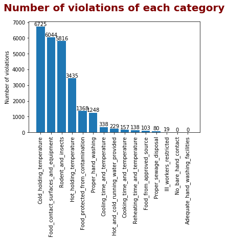

```python
#3a. create a bar chart show result of 2a
import matplotlib.pyplot as plt

#set the lables and titles

plt.ylabel('Number of violations')
plt.title('Number of violations of each category', fontdict={'fontsize': 20, 'fontweight': 700, 'color': 'maroon'}, pad=20)
plt.xticks(rotation='vertical')
bars = plt.bar(x=data5.index, height= data5['Numofviolances_bytype'])

#put texts on the chart
for p in bars:
    height = p.get_height()
    plt.annotate('{}'.format(height),xy=(p.get_x() + p.get_width() / 2, height), ha='center', va='bottom')
```

# 3b. create line chart show percentage of restaurants with at least one violation by month and year

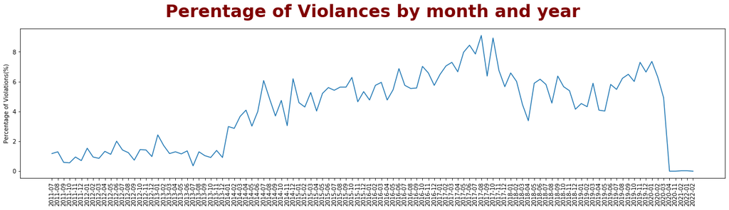

```python
#3b. create line chart show percentage of restaurants with at least one violation by month and year
#create a new column called percentaeg of each month and year for further analysis
data7= data.groupby('Inspected_YearandMonth',as_index=False)['If out of compliance'].sum()
data7['Percentage of Month']= round(((data7['If out of compliance'])/len(data.groupby('Establishment_id').count()))*100,2)
data7['Inspected_YearandMonth']=data7['Inspected_YearandMonth'].astype(str)

#change the size of graph so the x axies will be easier to see
plt.figure(figsize=(22,4.8))
plt.ylabel('Percentage of Violations(%)')
plt.title('Perentage of Violances by month and year', fontdict={'fontsize': 30, 'fontweight': 700, 'color': 'maroon'}, pad=20)
plt.xticks(rotation='vertical')
bars = plt.plot(data7['Inspected_YearandMonth'], data7['Percentage of Month'])
```

As we can see from the chart, the percentage of violance soared up starting from 2014, which we can infer that maybe the regulation has changed that year and cause restaurants got inspected more often. Also, the percentage dropped almost every April and November,we can infer that restaurants adjust their holding temperatures in order to meet the season change at that time. This action has made their temperature holding system, which is the most common violations among all types as we can see from the previous bar chart, fixed.

# 3c.create a map that show restaurants with violations

```python
#3c.create a map
import plotly.graph_objects as go
```

```python
#access token
mapbox_access_token = 'pk.eyJ1Ijoic3VuZ3p6enoiLCJhIjoiY2s5Z2k4M3hlMG83NTNmcGZieHU4cnB6eCJ9.0PFZ_YT52bktVJvKH0mVaA'
```

```python
data['Longitude']= data['Location'].str.extract('([-+]?\d*\.\d+|\d+)').astype(float)

data
```

|  | Establishment_id | Name | Category | Inspection_date | Inspection_results | City | State | Zip | Address_line_1 | Address_line_2 | ... | Location | Zip Codes | MultiValue or Not | Dummies | Inspected_Year | Inspected_Month | Inspected_YearandMonth | Violation Number | If out of compliance | Longitude |
| --- | --- | --- | --- | --- | --- | --- | --- | --- | --- | --- | --- | --- | --- | --- | --- | --- | --- | --- | --- | --- | --- |
| 0 | 8176 | LAUREL DUTCH MARKET - SAMMIE'S PRODUCE | Carry-out | 2019-09-05 | Critical Violations observed | LAUREL | MD | 20707.0 | 9701 FORT MEADE RD | ------ | ... | POINT (-76.838165 39.095491) | 15996.0 | False | 0 | 2019 | 9 | 2019-09 | 1 | 1 | -76.838165 |
| 1 | 14622 | JERSEY MIKE'S SUBS | Fast Food | 2019-09-06 | Critical Violations observed | Riverdale | MD | 20737.0 | 6761 45th ST | ------ | ... | NaN | NaN | False | 0 | 2019 | 9 | 2019-09 | 1 | 1 | NaN |
| 2 | 7273 | ACCOKEEK ACADEMY | Public School | 2019-09-09 | Non-Compliant - Violations Observed | ACCOKEEK | MD | 20607.0 | 14400 BERRY RD | ------ | ... | POINT (-76.980676 38.687531) | 8834.0 | False | 0 | 2019 | 9 | 2019-09 | 0 | 0 | -76.980676 |
| 3 | 2103 | PAPA JOHNS 728 | Carry-out | 2019-09-05 | Compliant - No Health Risk | BOWIE | MD | 20715.0 | 6852 RACE TRACK RD | ------ | ... | POINT (-76.729269 38.983881) | 16435.0 | False | 0 | 2019 | 9 | 2019-09 | 0 | 0 | -76.729269 |
| 4 | 347 | COLUMBIA PARK ELEMENTARY SCHOOL | Public School | 2019-09-05 | Critical Violations observed | LANDOVER | MD | 20785.0 | 1901 KENT VILLAGE DR | ------ | ... | POINT (-76.88767 38.91584) | 31451.0 | False | 0 | 2019 | 9 | 2019-09 | 2 | 1 | -76.887670 |
| ... | ... | ... | ... | ... | ... | ... | ... | ... | ... | ... | ... | ... | ... | ... | ... | ... | ... | ... | ... | ... | ... |
| 34731 | 2227 | SEVEN ELEVEN 11657B | Convenience Store | 2019-08-29 | Critical Violations observed | LANDOVER | MD | 20785.0 | 6001 ARBOR ST | ------ | ... | POINT (-76.916124 38.918599) | 31451.0 | False | 0 | 2019 | 8 | 2019-08 | 2 | 1 | -76.916124 |
| 34732 | 1161 | POLLO CABANA | Carry-out | 2019-08-29 | ------ | GREENBELT | MD | 20770.0 | 7423 GREENBELT RD | ------ | ... | POINT (-76.881531 38.994883) | 16242.0 | False | 0 | 2019 | 8 | 2019-08 | 0 | 0 | -76.881531 |
| 34733 | 8320 | PAISANOS COLLEGE PARK | Full Service | 2019-08-26 | Compliance Schedule - Completed | COLLEGE PARK | MD | 20740.0 | 7201 BALTIMORE AVE | B | ... | POINT (-76.93784 38.977805) | 15305.0 | False | 0 | 2019 | 8 | 2019-08 | 0 | 0 | -76.937840 |
| 34734 | 2268 | SIX FLAGS AMERICA - HURRICANE HOT DOGS | Stadium/Amusement Park | 2019-08-24 | Non-Compliant - Violations Observed | MITCHELLVILLE | MD | 20721.0 | 13710 CENTRAL AVE | ------ | ... | POINT (-76.775193 38.90087) | 17158.0 | True | 1 | 2019 | 8 | 2019-08 | 0 | 0 | -76.775193 |
| 34735 | 2511 | CVS PHARMACY 1489 | Convenience Store | 2019-08-28 | Non-Compliant - Violations Observed | LANDOVER | MD | 20785.0 | 6516 LANDOVER RD | ------ | ... | POINT (-76.900997 38.931946) | 31451.0 | False | 0 | 2019 | 8 | 2019-08 | 0 | 0 | -76.900997 |

34736 rows × 38 columns

```python
#set the longitude and latitude from location column
data['Latitude']= data['Location'].str.split()
data['Latitude']= data['Latitude'].str[2]
data['Latitude']=data['Latitude'].str.replace(')','').astype(float)
data
```

|  | Establishment_id | Name | Category | Inspection_date | Inspection_results | City | State | Zip | Address_line_1 | Address_line_2 | ... | Zip Codes | MultiValue or Not | Dummies | Inspected_Year | Inspected_Month | Inspected_YearandMonth | Violation Number | If out of compliance | Longitude | Latitude |
| --- | --- | --- | --- | --- | --- | --- | --- | --- | --- | --- | --- | --- | --- | --- | --- | --- | --- | --- | --- | --- | --- |
| 0 | 8176 | LAUREL DUTCH MARKET - SAMMIE'S PRODUCE | Carry-out | 2019-09-05 | Critical Violations observed | LAUREL | MD | 20707.0 | 9701 FORT MEADE RD | ------ | ... | 15996.0 | False | 0 | 2019 | 9 | 2019-09 | 1 | 1 | -76.838165 | 39.095491 |
| 1 | 14622 | JERSEY MIKE'S SUBS | Fast Food | 2019-09-06 | Critical Violations observed | Riverdale | MD | 20737.0 | 6761 45th ST | ------ | ... | NaN | False | 0 | 2019 | 9 | 2019-09 | 1 | 1 | NaN | NaN |
| 2 | 7273 | ACCOKEEK ACADEMY | Public School | 2019-09-09 | Non-Compliant - Violations Observed | ACCOKEEK | MD | 20607.0 | 14400 BERRY RD | ------ | ... | 8834.0 | False | 0 | 2019 | 9 | 2019-09 | 0 | 0 | -76.980676 | 38.687531 |
| 3 | 2103 | PAPA JOHNS 728 | Carry-out | 2019-09-05 | Compliant - No Health Risk | BOWIE | MD | 20715.0 | 6852 RACE TRACK RD | ------ | ... | 16435.0 | False | 0 | 2019 | 9 | 2019-09 | 0 | 0 | -76.729269 | 38.983881 |
| 4 | 347 | COLUMBIA PARK ELEMENTARY SCHOOL | Public School | 2019-09-05 | Critical Violations observed | LANDOVER | MD | 20785.0 | 1901 KENT VILLAGE DR | ------ | ... | 31451.0 | False | 0 | 2019 | 9 | 2019-09 | 2 | 1 | -76.887670 | 38.915840 |
| ... | ... | ... | ... | ... | ... | ... | ... | ... | ... | ... | ... | ... | ... | ... | ... | ... | ... | ... | ... | ... | ... |
| 34731 | 2227 | SEVEN ELEVEN 11657B | Convenience Store | 2019-08-29 | Critical Violations observed | LANDOVER | MD | 20785.0 | 6001 ARBOR ST | ------ | ... | 31451.0 | False | 0 | 2019 | 8 | 2019-08 | 2 | 1 | -76.916124 | 38.918599 |
| 34732 | 1161 | POLLO CABANA | Carry-out | 2019-08-29 | ------ | GREENBELT | MD | 20770.0 | 7423 GREENBELT RD | ------ | ... | 16242.0 | False | 0 | 2019 | 8 | 2019-08 | 0 | 0 | -76.881531 | 38.994883 |
| 34733 | 8320 | PAISANOS COLLEGE PARK | Full Service | 2019-08-26 | Compliance Schedule - Completed | COLLEGE PARK | MD | 20740.0 | 7201 BALTIMORE AVE | B | ... | 15305.0 | False | 0 | 2019 | 8 | 2019-08 | 0 | 0 | -76.937840 | 38.977805 |
| 34734 | 2268 | SIX FLAGS AMERICA - HURRICANE HOT DOGS | Stadium/Amusement Park | 2019-08-24 | Non-Compliant - Violations Observed | MITCHELLVILLE | MD | 20721.0 | 13710 CENTRAL AVE | ------ | ... | 17158.0 | True | 1 | 2019 | 8 | 2019-08 | 0 | 0 | -76.775193 | 38.900870 |
| 34735 | 2511 | CVS PHARMACY 1489 | Convenience Store | 2019-08-28 | Non-Compliant - Violations Observed | LANDOVER | MD | 20785.0 | 6516 LANDOVER RD | ------ | ... | 31451.0 | False | 0 | 2019 | 8 | 2019-08 | 0 | 0 | -76.900997 | 38.931946 |

34736 rows × 39 columns

```python
#drop the data with no longitude or latitude
data8= data.dropna(subset= ['Longitude','Latitude'])
data8
```

|  | Establishment_id | Name | Category | Inspection_date | Inspection_results | City | State | Zip | Address_line_1 | Address_line_2 | ... | Zip Codes | MultiValue or Not | Dummies | Inspected_Year | Inspected_Month | Inspected_YearandMonth | Violation Number | If out of compliance | Longitude | Latitude |
| --- | --- | --- | --- | --- | --- | --- | --- | --- | --- | --- | --- | --- | --- | --- | --- | --- | --- | --- | --- | --- | --- |
| 0 | 8176 | LAUREL DUTCH MARKET - SAMMIE'S PRODUCE | Carry-out | 2019-09-05 | Critical Violations observed | LAUREL | MD | 20707.0 | 9701 FORT MEADE RD | ------ | ... | 15996.0 | False | 0 | 2019 | 9 | 2019-09 | 1 | 1 | -76.838165 | 39.095491 |
| 2 | 7273 | ACCOKEEK ACADEMY | Public School | 2019-09-09 | Non-Compliant - Violations Observed | ACCOKEEK | MD | 20607.0 | 14400 BERRY RD | ------ | ... | 8834.0 | False | 0 | 2019 | 9 | 2019-09 | 0 | 0 | -76.980676 | 38.687531 |
| 3 | 2103 | PAPA JOHNS 728 | Carry-out | 2019-09-05 | Compliant - No Health Risk | BOWIE | MD | 20715.0 | 6852 RACE TRACK RD | ------ | ... | 16435.0 | False | 0 | 2019 | 9 | 2019-09 | 0 | 0 | -76.729269 | 38.983881 |
| 4 | 347 | COLUMBIA PARK ELEMENTARY SCHOOL | Public School | 2019-09-05 | Critical Violations observed | LANDOVER | MD | 20785.0 | 1901 KENT VILLAGE DR | ------ | ... | 31451.0 | False | 0 | 2019 | 9 | 2019-09 | 2 | 1 | -76.887670 | 38.915840 |
| 5 | 272 | CHECKERS DRIVE THRU RESTAURANT | Carry-out | 2019-09-10 | Compliance Schedule - Outstanding | COLLEGE PARK | MD | 20740.0 | 6051 GREENBELT RD | ------ | ... | 16242.0 | False | 0 | 2019 | 9 | 2019-09 | 0 | 0 | -76.910024 | 38.997563 |
| ... | ... | ... | ... | ... | ... | ... | ... | ... | ... | ... | ... | ... | ... | ... | ... | ... | ... | ... | ... | ... | ... |
| 34731 | 2227 | SEVEN ELEVEN 11657B | Convenience Store | 2019-08-29 | Critical Violations observed | LANDOVER | MD | 20785.0 | 6001 ARBOR ST | ------ | ... | 31451.0 | False | 0 | 2019 | 8 | 2019-08 | 2 | 1 | -76.916124 | 38.918599 |
| 34732 | 1161 | POLLO CABANA | Carry-out | 2019-08-29 | ------ | GREENBELT | MD | 20770.0 | 7423 GREENBELT RD | ------ | ... | 16242.0 | False | 0 | 2019 | 8 | 2019-08 | 0 | 0 | -76.881531 | 38.994883 |
| 34733 | 8320 | PAISANOS COLLEGE PARK | Full Service | 2019-08-26 | Compliance Schedule - Completed | COLLEGE PARK | MD | 20740.0 | 7201 BALTIMORE AVE | B | ... | 15305.0 | False | 0 | 2019 | 8 | 2019-08 | 0 | 0 | -76.937840 | 38.977805 |
| 34734 | 2268 | SIX FLAGS AMERICA - HURRICANE HOT DOGS | Stadium/Amusement Park | 2019-08-24 | Non-Compliant - Violations Observed | MITCHELLVILLE | MD | 20721.0 | 13710 CENTRAL AVE | ------ | ... | 17158.0 | True | 1 | 2019 | 8 | 2019-08 | 0 | 0 | -76.775193 | 38.900870 |
| 34735 | 2511 | CVS PHARMACY 1489 | Convenience Store | 2019-08-28 | Non-Compliant - Violations Observed | LANDOVER | MD | 20785.0 | 6516 LANDOVER RD | ------ | ... | 31451.0 | False | 0 | 2019 | 8 | 2019-08 | 0 | 0 | -76.900997 | 38.931946 |

34692 rows × 39 columns

```python
data10 = data8.set_index('Establishment_id').sort_index()
data10
```

| Establishment_id | Name | Category | Inspection_date | Inspection_results | City | State | Zip | Address_line_1 | Address_line_2 | Food_from_approved_source | ... | Zip Codes | MultiValue or Not | Dummies | Inspected_Year | Inspected_Month | Inspected_YearandMonth | Violation Number | If out of compliance | Longitude | Latitude |
| --- | --- | --- | --- | --- | --- | --- | --- | --- | --- | --- | --- | --- | --- | --- | --- | --- | --- | --- | --- | --- | --- |
| 1 | 301 BP | Gas Station Store | 2015-12-07 | Critical Violations observed | BRANDYWINE | MD | 20613.0 | 14807 CRAIN HWY | ------ | 0 | ... | 9221.0 | False | 0 | 2015 | 12 | 2015-12 | 1 | 1 | -76.872392 | 38.685163 |
| 1 | 301 BP | Gas Station Store | 2013-01-02 | ------ | BRANDYWINE | MD | 20613.0 | 14807 CRAIN HWY | ------ | 0 | ... | 9221.0 | False | 0 | 2013 | 1 | 2013-01 | 0 | 0 | -76.872392 | 38.685163 |
| 1 | 301 BP | Gas Station Store | 2014-06-17 | ------ | BRANDYWINE | MD | 20613.0 | 14807 CRAIN HWY | ------ | 0 | ... | 9221.0 | False | 0 | 2014 | 6 | 2014-06 | 0 | 0 | -76.872392 | 38.685163 |
| 1 | 301 BP | Gas Station Store | 2014-12-29 | Critical Violations observed | BRANDYWINE | MD | 20613.0 | 14807 CRAIN HWY | ------ | 0 | ... | 9221.0 | False | 0 | 2014 | 12 | 2014-12 | 1 | 1 | -76.872392 | 38.685163 |
| 1 | 301 BP | Gas Station Store | 2016-03-10 | Compliant - No Health Risk | BRANDYWINE | MD | 20613.0 | 14807 CRAIN HWY | ------ | 0 | ... | 9221.0 | False | 0 | 2016 | 3 | 2016-03 | 0 | 0 | -76.872392 | 38.685163 |
| ... | ... | ... | ... | ... | ... | ... | ... | ... | ... | ... | ... | ... | ... | ... | ... | ... | ... | ... | ... | ... | ... |
| 16019 | SOUL BOAT SEAFOOD MARKET | NaN | 2020-02-18 | ------ | LAUREL | MD | 20707.0 | 13929 BALTIMORE AVE | ------ | 0 | ... | 15996.0 | NaN | 0 | 2020 | 2 | 2020-02 | 0 | 0 | -76.863380 | 39.082769 |
| 16019 | SOUL BOAT SEAFOOD MARKET | NaN | 2020-02-07 | ------ | LAUREL | MD | 20707.0 | 13929 BALTIMORE AVE | ------ | 0 | ... | 15996.0 | NaN | 0 | 2020 | 2 | 2020-02 | 0 | 0 | -76.863380 | 39.082769 |
| 16056 | LA ESTANCIA RESTAURANT INC | Restaurant | 2020-03-11 | Compliant - No Health Risk | HYATTSVILLE | MD | 20784.0 | 6705 ANNAPOLIS RD | ------ | 0 | ... | 10891.0 | False | 0 | 2020 | 3 | 2020-03 | 0 | 0 | -76.902421 | 38.942729 |
| 16056 | LA ESTANCIA RESTAURANT INC | Restaurant | 2020-03-05 | Compliance Schedule - Completed | HYATTSVILLE | MD | 20784.0 | 6705 ANNAPOLIS RD | ------ | 0 | ... | 10891.0 | False | 0 | 2020 | 3 | 2020-03 | 0 | 0 | -76.902421 | 38.942729 |
| 16056 | LA ESTANCIA RESTAURANT INC | Restaurant | 2020-03-02 | Compliance Schedule - Outstanding | HYATTSVILLE | MD | 20784.0 | 6705 ANNAPOLIS RD | ------ | 0 | ... | 10891.0 | False | 0 | 2020 | 3 | 2020-03 | 0 | 0 | -76.902421 | 38.942729 |

34692 rows × 38 columns

```python
data11= pd.DataFrame(data8.groupby('Name')['Violation Number'].sum())
data11
```

| Name | Violation Number |
| --- | --- |
| & PIZZA | 2 |
| 1000 DEGREES PIZZA- WOODMORE | 4 |
| 2000 MART | 0 |
| 24 DISCOUNT MART CONVENIENCE & TOBACCO | 2 |
| 24 EXPRESS | 0 |
| ... | ... |
| ZHENG'S RESTAURANT | 16 |
| ZZ PIZZA AND KABOB | 30 |
| duplicate - 16059 do not use 528/6956 | 0 |
| duplicate - 16284 do not use | 1 |
| duplicate 16324 do not use | 5 |

3100 rows × 1 columns

```python
data11['Longitude']= data8.groupby('Name')['Longitude'].mean()
data11
```

| Name | Violation Number | Longitude |
| --- | --- | --- |
| & PIZZA | 2 | -76.958574 |
| 1000 DEGREES PIZZA- WOODMORE | 4 | -76.847420 |
| 2000 MART | 0 | -76.904807 |
| 24 DISCOUNT MART CONVENIENCE & TOBACCO | 2 | -76.922871 |
| 24 EXPRESS | 0 | -76.984742 |
| ... | ... | ... |
| ZHENG'S RESTAURANT | 16 | -76.903626 |
| ZZ PIZZA AND KABOB | 30 | -76.960769 |
| duplicate - 16059 do not use 528/6956 | 0 | -76.869698 |
| duplicate - 16284 do not use | 1 | -76.906597 |
| duplicate 16324 do not use | 5 | -76.897997 |

3100 rows × 2 columns

```python
data11['Latitude']= data8.groupby('Name')['Latitude'].mean()
data11
```

| Name | Violation Number | Longitude | Latitude |
| --- | --- | --- | --- |
| & PIZZA | 2 | -76.958574 | 38.966903 |
| 1000 DEGREES PIZZA- WOODMORE | 4 | -76.847420 | 38.922319 |
| 2000 MART | 0 | -76.904807 | 38.898128 |
| 24 DISCOUNT MART CONVENIENCE & TOBACCO | 2 | -76.922871 | 38.870862 |
| 24 EXPRESS | 0 | -76.984742 | 38.831510 |
| ... | ... | ... | ... |
| ZHENG'S RESTAURANT | 16 | -76.903626 | 38.960818 |
| ZZ PIZZA AND KABOB | 30 | -76.960769 | 38.938433 |
| duplicate - 16059 do not use 528/6956 | 0 | -76.869698 | 38.957452 |
| duplicate - 16284 do not use | 1 | -76.906597 | 38.843621 |
| duplicate 16324 do not use | 5 | -76.897997 | 38.784739 |

3100 rows × 3 columns

```python
data11['if violation']= data11['Violation Number'].apply(lambda p: 1 if p>0 else 0).astype(int)
data11
```

| Name | Violation Number | Longitude | Latitude | if violation |
| --- | --- | --- | --- | --- |
| & PIZZA | 2 | -76.958574 | 38.966903 | 1 |
| 1000 DEGREES PIZZA- WOODMORE | 4 | -76.847420 | 38.922319 | 1 |
| 2000 MART | 0 | -76.904807 | 38.898128 | 0 |
| 24 DISCOUNT MART CONVENIENCE & TOBACCO | 2 | -76.922871 | 38.870862 | 1 |
| 24 EXPRESS | 0 | -76.984742 | 38.831510 | 0 |
| ... | ... | ... | ... | ... |
| ZHENG'S RESTAURANT | 16 | -76.903626 | 38.960818 | 1 |
| ZZ PIZZA AND KABOB | 30 | -76.960769 | 38.938433 | 1 |
| duplicate - 16059 do not use 528/6956 | 0 | -76.869698 | 38.957452 | 0 |
| duplicate - 16284 do not use | 1 | -76.906597 | 38.843621 | 1 |
| duplicate 16324 do not use | 5 | -76.897997 | 38.784739 | 1 |

3100 rows × 4 columns

```python
data12 = data11[data11['if violation']==1]
data13 = data11[data11['if violation']==0]
```

```python
data12
```

| Name | Violation Number | Longitude | Latitude | if violation |
| --- | --- | --- | --- | --- |
| & PIZZA | 2 | -76.958574 | 38.966903 | 1 |
| 1000 DEGREES PIZZA- WOODMORE | 4 | -76.847420 | 38.922319 | 1 |
| 24 DISCOUNT MART CONVENIENCE & TOBACCO | 2 | -76.922871 | 38.870862 | 1 |
| 24/7 CONVENIENCE STORE | 4 | -76.872061 | 39.104004 | 1 |
| 25 HOUR MARKET | 4 | -76.882116 | 38.929166 | 1 |
| ... | ... | ... | ... | ... |
| Z-KABOB | 22 | -76.822911 | 38.895158 | 1 |
| ZHENG'S RESTAURANT | 16 | -76.903626 | 38.960818 | 1 |
| ZZ PIZZA AND KABOB | 30 | -76.960769 | 38.938433 | 1 |
| duplicate - 16284 do not use | 1 | -76.906597 | 38.843621 | 1 |
| duplicate 16324 do not use | 5 | -76.897997 | 38.784739 | 1 |

2634 rows × 4 columns

```python
data13
```

| Name | Violation Number | Longitude | Latitude | if violation |
| --- | --- | --- | --- | --- |
| 2000 MART | 0 | -76.904807 | 38.898128 | 0 |
| 24 EXPRESS | 0 | -76.984742 | 38.831510 | 0 |
| 2ND GRACE CATERING | 0 | -76.879293 | 39.000333 | 0 |
| 3 MOORE SISTERS CATERING | 0 | -76.879293 | 39.000333 | 0 |
| 301 NUTRITION SPOT | 0 | -76.808356 | 38.759512 | 0 |
| ... | ... | ... | ... | ... |
| YUFKA BAKERY | 0 | -76.853562 | 38.884688 | 0 |
| YUM COUTURE ENTERPRISE | 0 | -76.769008 | 38.972111 | 0 |
| YUMMY YUMMY | 0 | -76.922621 | 38.938917 | 0 |
| ZABICO LIFE LLC | 0 | -76.879293 | 39.000333 | 0 |
| duplicate - 16059 do not use 528/6956 | 0 | -76.869698 | 38.957452 | 0 |

466 rows × 4 columns

```python
mapbox_access_token = 'pk.eyJ1Ijoic3VuZ3p6enoiLCJhIjoiY2s5Z2k4M3hlMG83NTNmcGZieHU4cnB6eCJ9.0PFZ_YT52bktVJvKH0mVaA'
```

```python
import plotly.graph_objects as go

violation_data = go.Scattermapbox(
        lon = data12['Longitude'],
        lat = data12['Latitude'],
        hoverinfo='text',
        text = data12.index,
        mode = 'markers',
        marker = dict(
                    color = 'red',
                    symbol = 'circle',
                    opacity = .5,

                )
)

violation_data1 = go.Scattermapbox(
        lon = data13['Longitude'],
        lat = data13['Latitude'],
        hoverinfo='text',
        text= data13.index,
        mode = 'markers',
        marker = dict(
                    color = 'gray',
                    symbol = 'circle',
                    opacity = .5,

                )
)

violation_layout = go.Layout(
        title = 'Map of restaurants with violations',
        mapbox=go.layout.Mapbox(
            accesstoken=mapbox_access_token,
            zoom=1
        )
    )

class_map = go.Figure(data=[violation_data,violation_data1], layout=violation_layout)
class_map.show()
```

[interactive chart not shown]

As we can see from the graph, restaurants closer to DC tend to have more violations, but the resaon might be there are more restaurants around there. Another reason for that might be because the upper east side of dc has the higher crime rate, which might cause the decrease of restaurant quality. Some employees working over there might be criminals and they definitely will not be as serious about inspections as normal people.